# Project: Identify Customer Segments

In this project, I apply unsupervised learning techniques to identify segments of the population that form the core customer base for a mail-order sales company in Germany. These segments can then be used to direct marketing campaigns towards audiences that will have the highest expected rate of returns. The data used was provided by Udacity partners at Bertelsmann Arvato Analytics.

```python
import numpy as np
import pandas as pd
import matplotlib.pyplot as plt
import seaborn as sns
from sklearn.preprocessing import StandardScaler, RobustScaler, MinMaxScaler
from sklearn.decomposition import PCA
from sklearn.cluster import KMeans

%matplotlib inline
```

### Step 0: Load the Data

Each row of the demographics files represents a single person, but also includes information outside of individuals, including information about their household, building, and neighborhood. This information will be used to cluster the general population into groups with similar demographic properties. Then, we will see how the people in the customers dataset fit into those created clusters. The hope here is that certain clusters are over-represented in the customers data, as compared to the general population; those over-represented clusters will be assumed to be part of the core userbase. This information can then be used for further applications, such as targeting for a marketing campaign.

```python
# Load in the general demographics data.
azdias = pd.read_csv("Udacity_AZDIAS_Subset.csv", sep=";")

# Load in the feature summary file.
feat_info = pd.read_csv("AZDIAS_Feature_Summary.csv", sep=";")
```

```python
# Check the structure of the data after it's loaded (e.g. print the number of
# rows and columns, print the first few rows).
print("The general dataset has %s rows and %s columns" %(azdias.shape[0], azdias.shape[1]))
print("The summary dataset has %s rows and %s columns"  %(feat_info.shape[0], feat_info.shape[1]))
```

```
The general dataset has 891221 rows and 85 columns
The summary dataset has 85 rows and 4 columns
```

```python
display(azdias.head(5))
```

|  | AGER_TYP | ALTERSKATEGORIE_GROB | ANREDE_KZ | CJT_GESAMTTYP | FINANZ_MINIMALIST | FINANZ_SPARER | FINANZ_VORSORGER | FINANZ_ANLEGER | FINANZ_UNAUFFAELLIGER | FINANZ_HAUSBAUER | ... | PLZ8_ANTG1 | PLZ8_ANTG2 | PLZ8_ANTG3 | PLZ8_ANTG4 | PLZ8_BAUMAX | PLZ8_HHZ | PLZ8_GBZ | ARBEIT | ORTSGR_KLS9 | RELAT_AB |
| --- | --- | --- | --- | --- | --- | --- | --- | --- | --- | --- | --- | --- | --- | --- | --- | --- | --- | --- | --- | --- | --- |
| 0 | -1 | 2 | 1 | 2.0 | 3 | 4 | 3 | 5 | 5 | 3 | ... | NaN | NaN | NaN | NaN | NaN | NaN | NaN | NaN | NaN | NaN |
| 1 | -1 | 1 | 2 | 5.0 | 1 | 5 | 2 | 5 | 4 | 5 | ... | 2.0 | 3.0 | 2.0 | 1.0 | 1.0 | 5.0 | 4.0 | 3.0 | 5.0 | 4.0 |
| 2 | -1 | 3 | 2 | 3.0 | 1 | 4 | 1 | 2 | 3 | 5 | ... | 3.0 | 3.0 | 1.0 | 0.0 | 1.0 | 4.0 | 4.0 | 3.0 | 5.0 | 2.0 |
| 3 | 2 | 4 | 2 | 2.0 | 4 | 2 | 5 | 2 | 1 | 2 | ... | 2.0 | 2.0 | 2.0 | 0.0 | 1.0 | 3.0 | 4.0 | 2.0 | 3.0 | 3.0 |
| 4 | -1 | 3 | 1 | 5.0 | 4 | 3 | 4 | 1 | 3 | 2 | ... | 2.0 | 4.0 | 2.0 | 1.0 | 2.0 | 3.0 | 3.0 | 4.0 | 6.0 | 5.0 |

5 rows × 85 columns

The feature summary file contains a summary of properties for each demographics data column. I use this file to make cleaning decisions during this stage of the project.

The fourth column of the feature attributes summary (loaded in above as `feat_info`) documents the codes from the data dictionary that indicate missing or unknown data. While the file encodes this as a list (e.g. `[-1,0]`), this will get read in as a string object. As such, some parsing is needed in order to identify missing values and clean the data.

To do this, I create a new "missing_or_unknown" column, with the string values converted to integers where appropriate.

```python
# Create a copy of 'missing_or_unknown' column that is converted to floats
missing_values = []
for i in range(feat_info.shape[0]):
    attribute = feat_info["attribute"][i]
    sth = [value for value in feat_info["missing_or_unknown"][i].\
                                   replace("[","").replace("]","").split(",")]
    if 'XX' in sth:
        missing_values.append(sth)
    elif 'X' in sth:
        missing_values.append(sth)
    elif sth=='':
        missing_values.append(np.nan)
    else:
        missing_values.append(pd.to_numeric(sth))

feat_info['missing_or_unknown'] = missing_values

feat_info['missing_or_unknown'][57] = [-1, 'X']
feat_info['missing_or_unknown'][59] = [-1, 'XX']
```

I want to see how much data takes on a 'missing' or 'unknown' code, and how much data is naturally missing. To do this, I will count the number of 'NAs' in the dataset before and after replacing the missing codes. The difference between these values is the number of encoded missing values.

```python
natural_missing_values = azdias.isnull().sum().sum()
print("The number of naturally missing data points is ", natural_missing_values)
```

```
The number of naturally missing data points is  4896838
```

```python
#Replace values in dataset
for i in range(feat_info.shape[0]):
    attribute = feat_info["attribute"][i]
    azdias[attribute] = azdias[attribute].replace(feat_info["missing_or_unknown"][i], np.nan)
```

```python
total_missing_values = azdias.isnull().sum().sum()
encoded_missing_values = total_missing_values - natural_missing_values
print("There were {} encoded missing values in the dataset, which represents {}% of the total number of missing values in the dataset"
      .format(encoded_missing_values, round(encoded_missing_values/total_missing_values *100, 2)))
```

```
There were 3477091 encoded missing values in the dataset, which represents 41.52% of the total number of missing values in the dataset
```

#### Assess Missing Data in Each Column

Here I assess the number of missing data points in each column of the dataset.

```python
# counts of missing data there in each column of the dataset.
n_missing_column_data = azdias.isnull().sum(axis=0);

# what does this mean in terms of percentages?
prop_missing_column_data = n_missing_column_data/azdias.shape[0];
```

The following cell shows descriptive statistics about the number of missing data points per column in the ASDIAS dataset:

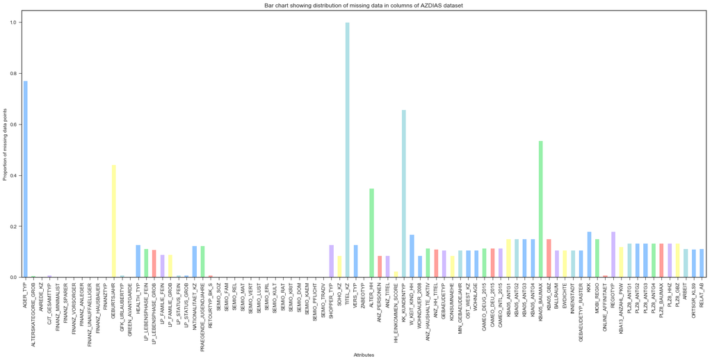

```python
# Investigate patterns in the amount of missing data in each column.
fig = plt.figure(figsize=(25,10))
ax = prop_missing_column_data.plot.bar()
ax.set_title("Bar chart showing distribution of missing data in columns of AZDIAS dataset")
ax.set_xlabel("Attributes")
ax.set_ylabel("Proportion of missing data points")
plt.show()
```

The distribution of these missing data points is further illustrated in the following violin and KDE plots.

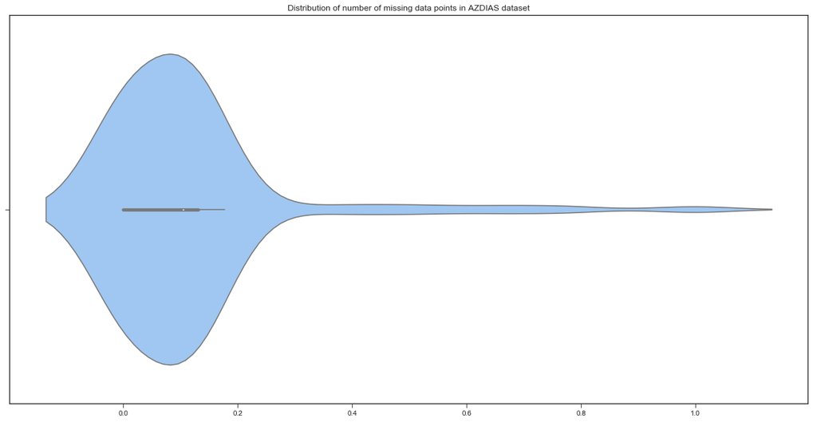

```python
sns.set_style("ticks")
sns.set_palette("pastel")
fig = plt.figure(figsize=(20,10))
ax = sns.violinplot(prop_missing_column_data)
ax.set_title("Distribution of number of missing data points in AZDIAS dataset")
plt.show()
```

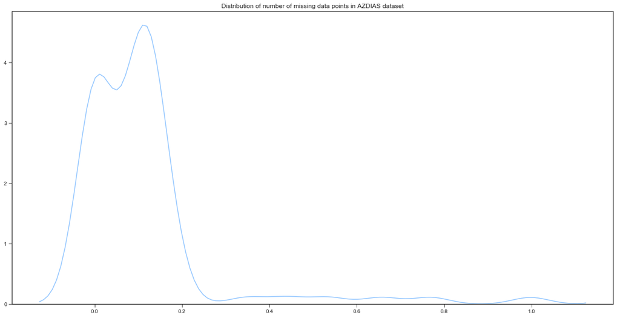

```python
sns.set_style("ticks")
sns.set_palette("pastel")
fig = plt.figure(figsize=(20,10))
ax = sns.kdeplot(prop_missing_column_data)
ax.set_title("Distribution of number of missing data points in AZDIAS dataset")
plt.show()
```

From the cells above, I see that the most columns have fewer than 20% of missing data points. I will eliminate any column which has more than 20% of missing data points.

```python
#The following columns are those I will drop:
columns_to_drop = list(n_missing_column_data[prop_missing_column_data >=0.2].index.values)
```

```python
azdias.drop(columns_to_drop, axis=1, inplace=True)
```

#### Discussion 1.1.2: Assess Missing Data in Each Column

I found that the data which represented similar features, but on different scales, tended to have similar amounts of missing data. For example 'CAMEO_DEU_2015', 'CAMEO_DEUG_2015', and 'CAMEO_INTL_2015', which are data on wealth/lifestyle topology on a rough, detailed and international scale respectively, have almost the same amount of missing data.

The columns with lots of missing data tended to be those of individual records, like people's titles, dates of birth, ageing, etc.

I removed six columns from the data: 'AGER_TYP', 'GEBURTSJAHR', 'TITEL_KZ', 'ALTER_HH', 'KK_KUNDENTYP', and 'KBA05_BAUMAX'.

#### Step 1.1.3: Assess Missing Data in Each Row

I now do the same for the rows in the dataset.

```python
# How much data is missing in each row of the dataset?
n_missing_row_data = azdias.isnull().sum(axis=1)

# what does that mean in terms of proportions?
prop_missing_row_data = n_missing_row_data/azdias.shape[1]
```

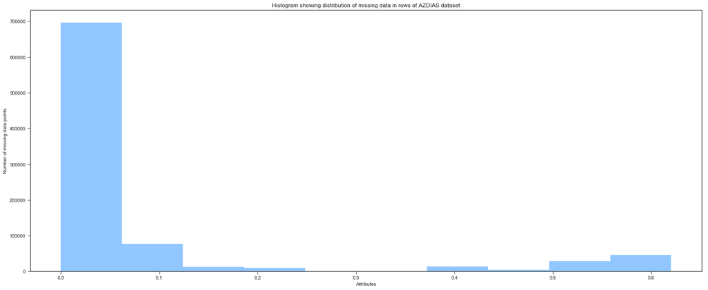

```python
# Investigate patterns in the amount of missing data in each row.
fig = plt.figure(figsize=(25,10))
sns.set_style("ticks")
ax = prop_missing_row_data.plot.hist()
ax.set_title("Histogram showing distribution of missing data in rows of AZDIAS dataset")
ax.set_xlabel("Attributes")
ax.set_ylabel("Number of missing data points")
plt.show()
```

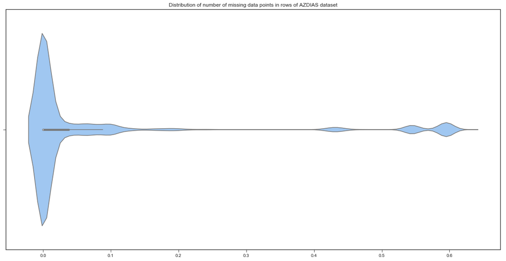

```python
#sns.set_style("darkgrid")
sns.set_palette("pastel")
fig = plt.figure(figsize=(20,10))
ax = sns.violinplot(prop_missing_row_data)
ax.set_title("Distribution of number of missing data points in rows of AZDIAS dataset")
plt.show()
```

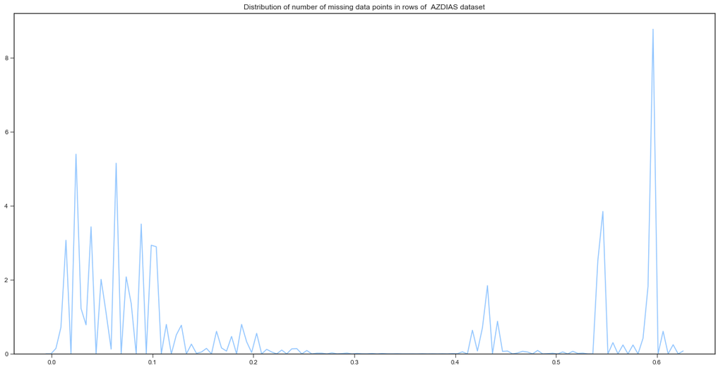

```python
sns.set_palette("pastel")
fig = plt.figure(figsize=(20,10))
ax = sns.kdeplot(prop_missing_row_data)
ax.set_title("Distribution of number of missing data points in rows of  AZDIAS dataset")
plt.show()
```

Now I divide the dataset into two subsets based on the number of missing values in each row. The first dataset is comprised of rows with no missing values at all, while the second dataset contains the rest of the datapoints.

```python
i=0
rows_wo_missing_values = list(np.where(n_missing_row_data <=i)[0])
rows_with_missing_values = list(np.where(n_missing_row_data >i)[0])

azdias_few_missing_values = azdias.loc[rows_wo_missing_values, :]
azdias_many_missing_values = azdias.loc[rows_with_missing_values, :]
```

Now I compare the distribution of values for five columns where there are no or few missing values, between the two subsets.

```python
def compare_distribution(column_name):
    fig = plt.figure(figsize=(10,5))
    fig.suptitle("Comparison of datasets with missing values and datasets without missing values")
    #fig.subplots(nrows=2, ncols=2, sharex='col', sharey='row')
    plt.subplot(1,2,1)
    ax1 = sns.countplot(data = azdias_few_missing_values, x=azdias_few_missing_values[column_name])
    ax1.set_xlabel("Values")
    ax1.set_ylabel("Counts")
    ax1.set_title("Dataset with no missing values")
    plt.subplot(1,2,2)
    ax2 = sns.countplot(data=azdias_many_missing_values, x=azdias_many_missing_values[column_name])
    ax2.set_title("Dataset with some missing values")
    ax2.set_xlabel("Values")
    ax2.set_ylabel("Counts")

    fig.tight_layout()
    fig.subplots_adjust(top=0.88, wspace=0.4)
    plt.show()
```

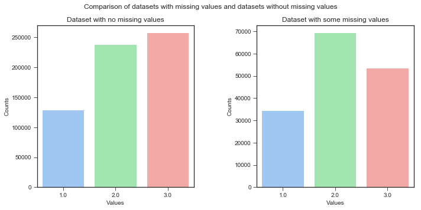

```python
compare_distribution('HEALTH_TYP')
```

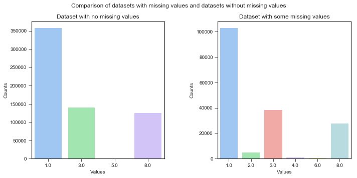

```python
compare_distribution('GEBAEUDETYP')
```

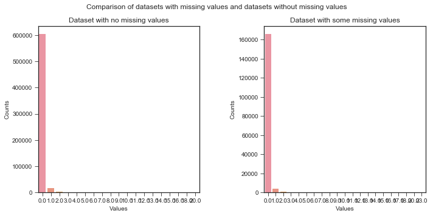

```python
compare_distribution('ANZ_HH_TITEL')
```

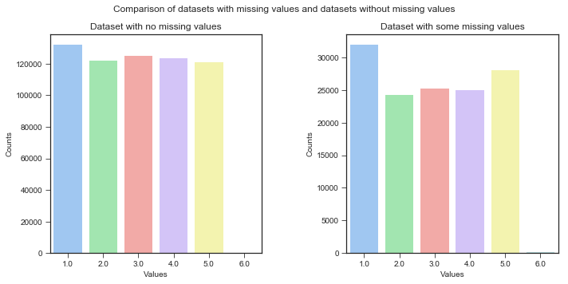

```python
compare_distribution('MOBI_REGIO')
```

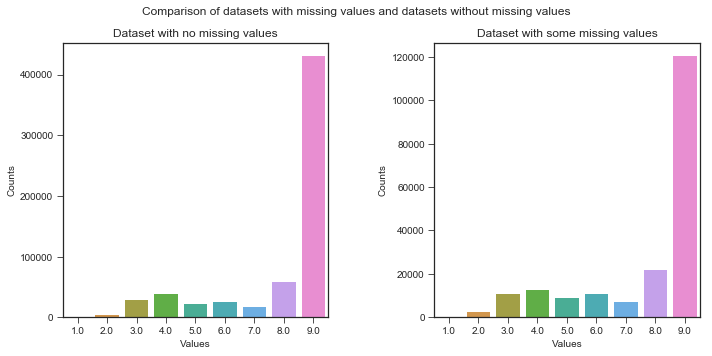

```python
compare_distribution('WOHNDAUER_2008')
```

#### Discussion 1.1.3: Assess Missing Data in Each Row

From the bar charts above, the distributions of values between both datasets are different for some features. For now, I will concentrate on the datasets with no missing values.

```python
azdias = azdias_few_missing_values
```

### Step 1.2: Select and Re-Encode Features

```python
# How many features are there of each data type?
for value in feat_info["type"].unique():
    print("There are {} {} features".format(feat_info[feat_info["type"]==value].shape[0],value))
```

```
There are 21 categorical features
There are 49 ordinal features
There are 7 numeric features
There are 7 mixed features
There are 1 interval features
```

#### Step 1.2.1: Re-Encode Categorical Features

```python
# Assess categorical variables: which are binary, which are multi-level, and
# which one needs to be re-encoded?
categorical_features = feat_info[feat_info["type"]=="categorical"]["attribute"]
```

```python
cat_features = pd.DataFrame()
features = []
n_categories = []
for feature in categorical_features:
    if feature in list(azdias):
        features.append(feature)
        n_categories.append(len(azdias[feature].unique()))
    else:
        pass

cat_features['features'] = features
cat_features['n_categories'] = n_categories
display(cat_features[cat_features.n_categories==2])
```

|  | features | n_categories |
| --- | --- | --- |
| 0 | ANREDE_KZ | 2 |
| 4 | GREEN_AVANTGARDE | 2 |
| 11 | SOHO_KZ | 2 |
| 12 | VERS_TYP | 2 |
| 15 | OST_WEST_KZ | 2 |

We see from the cell above that the following are binary features:

```
- ANREDE_KZ
- GREEN_AVANTGARDE
- SOHO_KZ
- VERS_TYP
- OST_WEST_KZ
```

*OST_WEST_KZ* is binary, but needs to be re-encoded, since it takes on non-numeric values ('W' for West and 'O' for East).

```python
# Re-encode categorical variable(s) to be kept in the analysis.
new_values = {'W': 1, 'O': 0}
azdias.replace({'OST_WEST_KZ':{'W': 1, 'O': 0}}, inplace=True)
```

```python
cat_features[cat_features.n_categories>3]
```

|  | features | n_categories |
| --- | --- | --- |
| 1 | CJT_GESAMTTYP | 6 |
| 2 | FINANZTYP | 6 |
| 3 | GFK_URLAUBERTYP | 12 |
| 5 | LP_FAMILIE_FEIN | 11 |
| 6 | LP_FAMILIE_GROB | 5 |
| 7 | LP_STATUS_FEIN | 10 |
| 8 | LP_STATUS_GROB | 5 |
| 10 | SHOPPER_TYP | 4 |
| 13 | ZABEOTYP | 6 |
| 14 | GEBAEUDETYP | 4 |
| 16 | CAMEO_DEUG_2015 | 9 |
| 17 | CAMEO_DEU_2015 | 44 |

#### Discussion 1.2.1: Re-Encode Categorical Features

From looking at the description of the remaining categorical features in the dataset, I came to the following conclusions:

- 'CACAMEO_DEUG_2015' and 'CAMEO_DEU_2015' both describe the wealth and life stage typology, albeit at different scales. I will keep 'CAMEO_DEUG_2015', that which describes the typology at the rough scale.
- The same is true of 'LP_FAMILIE_FEIN' and 'LP_FAMILIE_GROB' and 'LP_STATUS_FEIN' and 'LP_STATUS_GROB'.

I also drop 'GEBAEUDETYP', which is a building-level feature, which simply describes the types of buildings.

As a result, I will drop the following columns: 'GEBAEUDETYP', 'CAMEO_DEU_2015', 'LP_STATUS_FEIN' and 'LP_FAMILLE_FEIN'. This will be done in the cells below, as well as one-hot-encoding the remaining variables.

```python
cat_columns_to_drop =['CAMEO_DEU_2015','LP_STATUS_FEIN','LP_FAMILIE_FEIN', 'GEBAEUDETYP']
```

```python
azdias = pd.get_dummies(azdias, columns=['NATIONALITAET_KZ', 'CJT_GESAMTTYP', 'FINANZTYP', 'GFK_URLAUBERTYP', 'LP_FAMILIE_GROB', 'LP_STATUS_GROB',
                               'SHOPPER_TYP', 'ZABEOTYP', 'CAMEO_DEUG_2015']);
```

#### Step 1.2.2: Engineer Mixed-Type Features

There are a handful of features that are marked as "mixed" in the feature summary that require special treatment in order to be included in the analysis.

- "PRAEGENDE_JUGENDJAHRE" combines information on three dimensions: generation by decade, movement (mainstream vs. avantgarde), and nation (east vs. west). I create two new variables to capture the other two dimensions: an interval-type variable for decade, and a binary variable for movement.
- "CAMEO_INTL_2015" combines information on two axes: wealth and life stage. I break up the two-digit codes by their 'tens'-place and 'ones'-place digits into two new ordinal variables (which, for the purposes of this project, is equivalent to just treating them as their raw numeric values).

```python
# Investigate "PRAEGENDE_JUGENDJAHRE" and engineer two new variables.
azdias['PJ_decade'] = azdias['PRAEGENDE_JUGENDJAHRE']
azdias['PJ_movement'] = azdias['PRAEGENDE_JUGENDJAHRE']
```

I created two new columns: 'PJ_DECADE' to capture the decade dimension, and 'PJ_movement' to capture the movement.

For 'PJ_decade', I created six new categories, one for each decade represented in the data.

For 'PJ_movement', I created a binary variable. 1 represents the Mainstream movement, while 2 represents the Avantgarde movement

```python
decade_values = {2:1, 3:2, 4:2, 5:3, 6:3, 7:3, 8:4, 9:4, 10:5, 11:5, 12:5, 13:5, 14:6, 15:6}
azdias['PJ_decade'].replace(decade_values, inplace=True)

movement_values = {3:1, 5:1, 8:1 ,10:1, 12:1, 14:1,  4:2, 6:2, 7:2, 9:2, 11:2, 13:2, 15:2}
azdias['PJ_movement'].replace(movement_values, inplace=True)
```

```python
# Investigate "CAMEO_INTL_2015" and engineer two new variables.
azdias['CAMEO_INTL_wealth'] = azdias['CAMEO_INTL_2015']
azdias['CAMEO_INTL_life_stage'] = azdias['CAMEO_INTL_2015']
```

```python
#Splitting values into tens and ones
life_topology_values={}
wealth_values = {}
for value in azdias['CAMEO_INTL_2015'].unique():
    life_topology_values[value]=divmod(int(value),10)[1]
    wealth_values[value] = divmod(int(value),10)[0]
```

```python
#Replacing new columns with new values
azdias['CAMEO_INTL_wealth'].replace(wealth_values, inplace=True)
azdias['CAMEO_INTL_life_stage'].replace(life_topology_values, inplace=True)
```

```python
mixed_features = feat_info[feat_info["type"]=="mixed"]["attribute"]

for feature in mixed_features:
    if feature in list(azdias):
        print(feature)
    else:
        pass
```

```
LP_LEBENSPHASE_FEIN
LP_LEBENSPHASE_GROB
PRAEGENDE_JUGENDJAHRE
WOHNLAGE
CAMEO_INTL_2015
PLZ8_BAUMAX
```

```python
# Separating  building types in the PLZ8_BAUMAX feature

building_types = {2:1, 3:1, 4:1, 5:2}
azdias['PLZ8_BAUMAX_buildings'] = azdias['PLZ8_BAUMAX']
azdias['PLZ8_BAUMAX_buildings'].replace(building_types, inplace=True)
```

```python
# Add the other mixed columns to the to-drop list

cat_columns_to_drop.extend(['PRAEGENDE_JUGENDJAHRE', 'WOHNLAGE', 'LP_LEBENSPHASE_FEIN', 'LP_LEBENSPHASE_GROB', 'CAMEO_DEU_2015',
                    'CAMEO_INTL_2015'])
```

#### Discussion 1.2.2: Engineer Mixed-Type Features

I kept the 'PLZ8_BAUMAX' feature, because I found it easy, and reasonable to separate the building types in the region into family and business type buildings. So I grouped all the family homes into one category, irrespective of the size, and left the business buildings in a category of its own.

I will drop the 'LP_LEBENSPHASE_FEIN and LP_LEBENSPHASE_GROB features, because they were too cumbersome to separate appropriately, and the 'WOHNLAGE' feature because I didn't find any reasonable way to aggregate the subdivisions between features.

```python
# Now dropping the other columns
azdias.drop(cat_columns_to_drop, axis=1, inplace=True)
```

```python
azdias.head()
```

|  | ALTERSKATEGORIE_GROB | ANREDE_KZ | FINANZ_MINIMALIST | FINANZ_SPARER | FINANZ_VORSORGER | FINANZ_ANLEGER | FINANZ_UNAUFFAELLIGER | FINANZ_HAUSBAUER | GREEN_AVANTGARDE | HEALTH_TYP | ... | CAMEO_DEUG_2015_5 | CAMEO_DEUG_2015_6 | CAMEO_DEUG_2015_7 | CAMEO_DEUG_2015_8 | CAMEO_DEUG_2015_9 | PJ_decade | PJ_movement | CAMEO_INTL_wealth | CAMEO_INTL_life_stage | PLZ8_BAUMAX_buildings |
| --- | --- | --- | --- | --- | --- | --- | --- | --- | --- | --- | --- | --- | --- | --- | --- | --- | --- | --- | --- | --- | --- |
| 1 | 1.0 | 2 | 1 | 5 | 2 | 5 | 4 | 5 | 0 | 3.0 | ... | 0 | 0 | 0 | 1 | 0 | 6.0 | 1.0 | 5 | 1 | 1.0 |
| 2 | 3.0 | 2 | 1 | 4 | 1 | 2 | 3 | 5 | 1 | 3.0 | ... | 0 | 0 | 0 | 0 | 0 | 6.0 | 2.0 | 2 | 4 | 1.0 |
| 4 | 3.0 | 1 | 4 | 3 | 4 | 1 | 3 | 2 | 0 | 3.0 | ... | 0 | 1 | 0 | 0 | 0 | 4.0 | 1.0 | 4 | 3 | 1.0 |
| 5 | 1.0 | 2 | 3 | 1 | 5 | 2 | 2 | 5 | 0 | 3.0 | ... | 0 | 0 | 0 | 1 | 0 | 2.0 | 1.0 | 5 | 4 | 1.0 |
| 6 | 2.0 | 2 | 1 | 5 | 1 | 5 | 4 | 3 | 0 | 2.0 | ... | 0 | 0 | 0 | 0 | 0 | 5.0 | 1.0 | 2 | 2 | 1.0 |

5 rows × 122 columns

### Step 1.3: A Cleaning Function

The following the function will execute the main feature selection, encoding, and re-engineering steps I performed above for any similar dataset. I will use this later when working with the customer dataset.

```python
def clean_data(df):
    """
    Perform feature trimming, re-encoding, and engineering for demographics
    data

    INPUT: Demographics DataFrame
    OUTPUT: Trimmed and cleaned demographics DataFrame
    """

    # Put in code here to execute all main cleaning steps:
    # convert missing value codes into NaNs, ...
    for i in range(feat_info.shape[0]):
        attribute = feat_info["attribute"][i]
        df[attribute] = df[attribute].replace(feat_info["missing_or_unknown"][i], np.nan)

    # remove selected columns and rows, ...
    columns_to_drop = ['AGER_TYP', 'GEBURTSJAHR', 'TITEL_KZ', 'ALTER_HH', 'KK_KUNDENTYP', 'KBA05_BAUMAX']
    df.drop(columns_to_drop, axis=1, inplace=True)


    row_error_threshold = 0
    n_missing_row_data = df.isnull().sum(axis=1)
    rows_wo_missing_values = list(np.where(n_missing_row_data <=row_error_threshold)[0])
    df = df.loc[rows_wo_missing_values, :]

    # select, re-encode, and engineer column values.
    df.replace({'OST_WEST_KZ':{'W': 1, 'O': 0}}, inplace=True)

    categorical_features = feat_info[feat_info["type"]=="categorical"]["attribute"]
    cat_columns_to_drop = ['CAMEO_DEU_2015','LP_STATUS_FEIN','GEBAEUDETYP','LP_FAMILIE_FEIN']

    df = pd.get_dummies(df, columns=['NATIONALITAET_KZ', 'CJT_GESAMTTYP', 'FINANZTYP', 'GFK_URLAUBERTYP', 'LP_FAMILIE_GROB', 'LP_STATUS_GROB',
                               'SHOPPER_TYP', 'ZABEOTYP', 'CAMEO_DEUG_2015'], sparse=True);

    df['PJ_decade'] = df['PRAEGENDE_JUGENDJAHRE']
    df['PJ_movement'] = df['PRAEGENDE_JUGENDJAHRE']

    decade_values = {2:1, 3:2, 4:2, 5:3, 6:3, 7:3, 8:4, 9:4, 10:5, 11:5, 12:5, 13:5, 14:6, 15:6}
    df['PJ_decade'].replace(decade_values, inplace=True)

    movement_values = {3:1, 5:1, 8:1 ,10:1, 12:1, 14:1,  4:2, 6:2, 7:2, 9:2, 11:2, 13:2, 15:2}
    df['PJ_movement'].replace(movement_values, inplace=True)

    df['CAMEO_INTL_wealth'] = df['CAMEO_INTL_2015']
    df['CAMEO_INTL_life_stage'] = df['CAMEO_INTL_2015']

    life_topology_values={}
    wealth_values = {}
    for value in df['CAMEO_INTL_2015'].unique():
        life_topology_values[value]=divmod(int(value),10)[1]
        wealth_values[value] = divmod(int(value),10)[0]
    df['CAMEO_INTL_wealth'].replace(wealth_values, inplace=True)
    df['CAMEO_INTL_life_stage'].replace(life_topology_values, inplace=True)

    building_types = {2:1, 3:1, 4:1, 5:2}

    df['PLZ8_BAUMAX_buildings'] = df['PLZ8_BAUMAX']
    df['PLZ8_BAUMAX_buildings'].replace(building_types, inplace=True)

    cat_columns_to_drop.extend(['PRAEGENDE_JUGENDJAHRE', 'WOHNLAGE', 'LP_LEBENSPHASE_FEIN',
                                'LP_LEBENSPHASE_GROB', 'CAMEO_DEU_2015', 'CAMEO_INTL_2015'])
    df = df.drop(cat_columns_to_drop, axis=1)

    # Return the cleaned dataframe.
    return df
```

## Step 2: Feature Transformation

### Step 2.1: Apply Feature Scaling

```python
if azdias.isnull().sum().sum() == 0:
    print("There are no NaN values in the dataset at this stage, we can continue with the analysis")
else:
    print("There are still some missing values in this dataset, please go back and clean your data properly")
```

```
There are no NaN values in the dataset at this stage, we can continue with the analysis
```

At this stage I rescale all the data in the dataset, so that differences in units, ranges, etc., do not intefere with the analysis.

In the following cells I compare three scaling functions in scikit-learn - the standard scaler, robust scaler, and the minmax scaler, to see if there is any major differences to the transformed dataset when they are applied.

```python
def compare_scalers(features: list):
    """
    compares three different scaling functions from scikitlearn
    INPUT: a list of features to be transformed under the different scalers
    Returns: plots of the unscaled data, and the transformed data
    """
    scaler = StandardScaler()
    standard_scaled_azdias = scaler.fit_transform(azdias)
    standard_scaled_azdias = pd.DataFrame(standard_scaled_azdias, columns=list(azdias))

    scaler = RobustScaler()
    robust_scaled_azdias = scaler.fit_transform(azdias)
    robust_scaled_azdias = pd.DataFrame(robust_scaled_azdias, columns=list(azdias))

    scaler = MinMaxScaler()
    minmax_scaled_azdias = scaler.fit_transform(azdias)
    minmax_scaled_azdias = pd.DataFrame(minmax_scaled_azdias, columns=list(azdias))

    fig, (ax1, ax2, ax3, ax4) = plt.subplots(ncols=4, figsize=(20, 10))

    for feature in features:
        ax1.set_title('Before Scaling')
        sns.kdeplot(azdias[feature], ax=ax1)
        ax2.set_title('After Standard Scaler')
        sns.kdeplot(standard_scaled_azdias[feature], ax=ax2)
        ax3.set_title('After MinMax Scaler')
        sns.kdeplot(minmax_scaled_azdias[feature], ax=ax3)
        ax4.set_title('After Robust Scaler')
        sns.kdeplot(robust_scaled_azdias[feature], ax=ax4)
    plt.show()
```

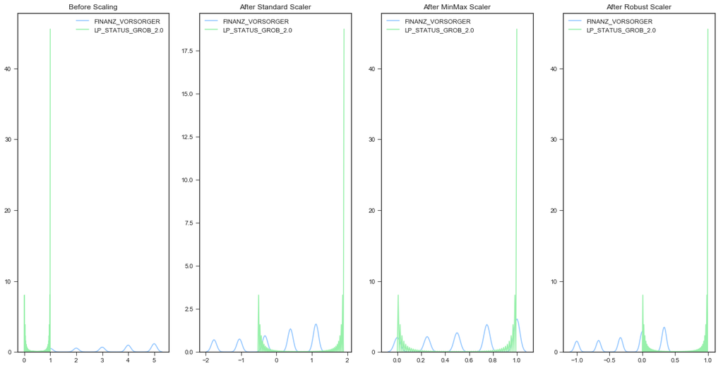

```python
np.random.seed(123)
to_be_compared =list(np.random.choice(list(azdias), size=2, replace=False))
compare_scalers(to_be_compared)
```

### Discussion 2.1: Apply Feature Scaling

I do not see any major qualitative difference in the data after applying these scalers. As such I think I can choose any one of them.

Because we have a large amount of data, we can assume a normal distribution on the data (from the Central Limit Theorem).

I make this assumption, and go ahead to use the Standard Scaler for the data

```python
scaler = StandardScaler()
standard_scaled_azdias = scaler.fit_transform(azdias)
standard_scaled_azdias = pd.DataFrame(standard_scaled_azdias, columns=list(azdias))
```

### Step 2.2: Dimensionality Reduction

```python
# Apply PCA to the data.
pca = PCA()
pca.fit(standard_scaled_azdias);
```

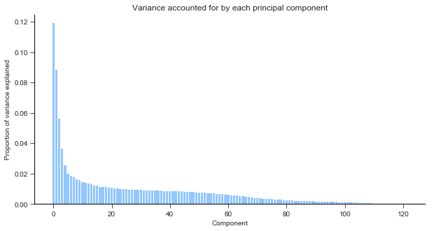

```python
fig = plt.figure(figsize=(10,5))
plt.bar(range(len(pca.explained_variance_ratio_)), pca.explained_variance_ratio_)
plt.xlabel("Component")
plt.ylabel("Proportion of variance explained")
plt.title("Variance accounted for by each principal component")
sns.despine()
plt.show()
```

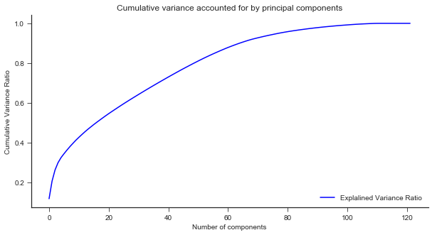

```python
# Investigate the variance accounted for by each principal component.

N = len(pca.explained_variance_ratio_)
x = range(N)
y1 = np.cumsum(pca.explained_variance_ratio_)
y2 = np.empty(N)
y2.fill(0.85)

fig = plt.figure(figsize=(10,5))
sns.set_style("ticks")
plt.plot(x,y1, '-', color='b', label='Explalined Variance Ratio')
plt.xlabel('Number of components')
plt.ylabel('Cumulative Variance Ratio')
plt.title("Cumulative variance accounted for by principal components")
sns.despine()
plt.legend(loc="lower right")
plt.show()
```

```python
threshold = 0.85
number_components = int(np.argwhere(y1>=threshold)[1])
print("We retain {} components for analysis because they explain {}% of the variance in the data."
      .format(number_components, int(threshold*100)))
```

```
We retain 57 components for analysis because they explain 85% of the variance in the data.
```

```python
# Re-apply PCA to the data while selecting for number of components to retain.
pca = PCA(n_components=number_components)
azdias = pca.fit_transform(standard_scaled_azdias);
```

```python
azdias = pd.DataFrame(azdias)
azdias.head()
```

|  | 0 | 1 | 2 | 3 | 4 | 5 | 6 | 7 | 8 | 9 | ... | 47 | 48 | 49 | 50 | 51 | 52 | 53 | 54 | 55 | 56 |
| --- | --- | --- | --- | --- | --- | --- | --- | --- | --- | --- | --- | --- | --- | --- | --- | --- | --- | --- | --- | --- | --- |
| 0 | 4.467724 | -2.815960 | -3.116388 | 0.132438 | -0.575009 | 2.613988 | 3.560230 | 0.116854 | -0.358352 | -1.061992 | ... | -1.419563 | -0.701671 | 1.607771 | -0.051930 | 2.784911 | -3.017380 | -0.791595 | 3.134223 | 1.054680 | -1.329812 |
| 1 | -0.530501 | -0.914601 | -3.599640 | 1.656466 | -3.150668 | 0.144650 | 0.279125 | -1.025689 | -0.491854 | -1.006495 | ... | -0.607049 | 0.872470 | 1.277565 | 0.651900 | 0.123208 | 0.545344 | 0.137397 | -0.234637 | -0.080845 | -0.839817 |
| 2 | 0.002334 | 0.116396 | 2.964336 | 0.671699 | 2.546701 | 2.908516 | -3.151420 | -1.922829 | 0.690466 | -0.800474 | ... | 0.383987 | 0.179719 | -0.818790 | 1.424593 | -0.333354 | -0.365974 | 0.907713 | 0.304432 | 0.792339 | -0.396214 |
| 3 | -0.904852 | -1.253940 | -0.976009 | -2.960292 | -3.048133 | 1.751891 | -0.131755 | 0.103609 | 0.495866 | 1.438173 | ... | 1.407939 | -0.185185 | 0.950980 | -2.186375 | -0.424007 | -0.818309 | 0.052236 | 0.435205 | -0.453486 | -0.018807 |
| 4 | 0.937279 | -3.877471 | -3.303319 | -1.127390 | -2.208561 | -0.000731 | -1.098345 | 0.060066 | -0.236706 | -0.311370 | ... | -0.587885 | 0.368949 | -1.269565 | -0.752431 | -0.402560 | 0.586668 | 0.122908 | 1.130121 | 0.078965 | -0.996647 |

5 rows × 57 columns

### Step 2.3: Interpret Principal Components

```python
# Map weights for the first principal component to corresponding feature names
# and then print the linked values, sorted by weight.

def pca_results(pca, i):
    df = pd.DataFrame(pca.components_, columns=list(standard_scaled_azdias.columns))
    component = df.iloc[i].sort_values()
    return component
```

```python
print(pca_results(pca, 0))
```

```
MOBI_REGIO              -0.205030
FINANZ_MINIMALIST       -0.200890
KBA05_ANTG1             -0.192513
PLZ8_ANTG1              -0.187695
KBA05_GBZ               -0.181714
PLZ8_GBZ                -0.141685
KONSUMNAEHE             -0.135146
INNENSTADT              -0.130393
ALTERSKATEGORIE_GROB    -0.122531
LP_STATUS_GROB_5.0      -0.119299
FINANZ_VORSORGER        -0.116442
CAMEO_INTL_life_stage   -0.115419
PJ_movement             -0.108074
GREEN_AVANTGARDE        -0.108074
LP_STATUS_GROB_4.0      -0.103928
GEBAEUDETYP_RASTER      -0.097492
BALLRAUM                -0.097277
FINANZTYP_2             -0.093315
SEMIO_LUST              -0.089093
ZABEOTYP_1              -0.088018
CAMEO_DEUG_2015_2       -0.083704
SEMIO_ERL               -0.081918
ANZ_PERSONEN            -0.075779
CAMEO_DEUG_2015_4       -0.071841
NATIONALITAET_KZ_1.0    -0.070418
KBA13_ANZAHL_PKW        -0.067711
CAMEO_DEUG_2015_3       -0.063828
WOHNDAUER_2008          -0.062804
CJT_GESAMTTYP_2.0       -0.060094
LP_FAMILIE_GROB_5.0     -0.058975
                           ...
LP_FAMILIE_GROB_1.0      0.076199
FINANZ_ANLEGER           0.078251
SEMIO_MAT                0.079580
FINANZ_UNAUFFAELLIGER    0.080135
CAMEO_DEUG_2015_8        0.088605
ZABEOTYP_5               0.089969
SEMIO_RAT                0.093894
SEMIO_TRADV              0.099561
RELAT_AB                 0.105370
SEMIO_REL                0.106094
PJ_decade                0.108917
SEMIO_PFLICHT            0.111255
CAMEO_DEUG_2015_9        0.112108
ANZ_HAUSHALTE_AKTIV      0.114389
KBA05_ANTG3              0.115453
ARBEIT                   0.115722
PLZ8_ANTG2               0.121359
PLZ8_BAUMAX_buildings    0.122328
FINANZTYP_1              0.124767
KBA05_ANTG4              0.128161
FINANZ_HAUSBAUER         0.132627
FINANZ_SPARER            0.144403
EWDICHTE                 0.153412
ORTSGR_KLS9              0.156141
HH_EINKOMMEN_SCORE       0.178695
CAMEO_INTL_wealth        0.178743
PLZ8_BAUMAX              0.180703
PLZ8_ANTG4               0.180994
PLZ8_ANTG3               0.184657
LP_STATUS_GROB_1.0       0.192255
Name: 0, Length: 122, dtype: float64
```

```python
# Map weights for the second principal component to corresponding feature names
# and then print the linked values, sorted by weight.
print(pca_results(pca, 1))
```

```
PJ_decade               -0.225571
SEMIO_REL               -0.219160
FINANZ_SPARER           -0.207081
FINANZ_UNAUFFAELLIGER   -0.206628
SEMIO_PFLICHT           -0.205414
SEMIO_TRADV             -0.202158
FINANZ_ANLEGER          -0.186241
SEMIO_KULT              -0.173851
ONLINE_AFFINITAET       -0.162098
SEMIO_RAT               -0.155431
SEMIO_FAM               -0.137490
SEMIO_MAT               -0.123364
FINANZTYP_1             -0.111645
ZABEOTYP_4              -0.102365
PLZ8_ANTG1              -0.100804
MOBI_REGIO              -0.097903
KBA05_GBZ               -0.093907
FINANZTYP_4             -0.093850
KBA05_ANTG1             -0.090402
FINANZTYP_3             -0.081514
ZABEOTYP_1              -0.081469
PLZ8_GBZ                -0.080097
ZABEOTYP_5              -0.078437
INNENSTADT              -0.074603
ANZ_PERSONEN            -0.071938
SEMIO_SOZ               -0.071923
KONSUMNAEHE             -0.070731
GFK_URLAUBERTYP_9.0     -0.068473
SHOPPER_TYP_0.0         -0.064584
LP_FAMILIE_GROB_4.0     -0.064485
                           ...
HH_EINKOMMEN_SCORE       0.058977
PLZ8_BAUMAX_buildings    0.061121
ANZ_HAUSHALTE_AKTIV      0.062969
RELAT_AB                 0.063905
FINANZTYP_6              0.064052
PLZ8_ANTG2               0.065009
LP_FAMILIE_GROB_1.0      0.066572
CJT_GESAMTTYP_1.0        0.066631
ARBEIT                   0.070039
KBA05_ANTG4              0.070808
FINANZTYP_2              0.074178
SHOPPER_TYP_3.0          0.075692
SEMIO_KAEM               0.078417
CAMEO_INTL_wealth        0.083444
EWDICHTE                 0.090028
ORTSGR_KLS9              0.090337
FINANZTYP_5              0.090400
SEMIO_KRIT               0.092927
PLZ8_BAUMAX              0.094714
PLZ8_ANTG4               0.097051
CJT_GESAMTTYP_2.0        0.099712
PLZ8_ANTG3               0.100170
FINANZ_HAUSBAUER         0.112807
W_KEIT_KIND_HH           0.124273
RETOURTYP_BK_S           0.154095
SEMIO_LUST               0.155070
SEMIO_ERL                0.189141
ZABEOTYP_3               0.201419
FINANZ_VORSORGER         0.202995
ALTERSKATEGORIE_GROB     0.224451
Name: 1, Length: 122, dtype: float64
```

```python
# Map weights for the third principal component to corresponding feature names
# and then print the linked values, sorted by weight.
print(pca_results(pca, 2))
```

```
ANREDE_KZ               -0.348743
SEMIO_KAEM              -0.321968
SEMIO_DOM               -0.292327
SEMIO_KRIT              -0.263788
SEMIO_ERL               -0.191421
SEMIO_RAT               -0.174966
FINANZ_ANLEGER          -0.161753
SHOPPER_TYP_2.0         -0.111794
FINANZTYP_1             -0.108080
PJ_decade               -0.071819
ZABEOTYP_4              -0.070869
FINANZ_SPARER           -0.069065
FINANZ_UNAUFFAELLIGER   -0.059574
FINANZ_HAUSBAUER        -0.054848
LP_FAMILIE_GROB_3.0     -0.052370
INNENSTADT              -0.051029
PLZ8_ANTG1              -0.047103
SHOPPER_TYP_3.0         -0.046493
KONSUMNAEHE             -0.045057
BALLRAUM                -0.043885
SEMIO_TRADV             -0.043681
SEMIO_PFLICHT           -0.040560
GEBAEUDETYP_RASTER      -0.037506
PLZ8_GBZ                -0.036847
HH_EINKOMMEN_SCORE      -0.036823
ONLINE_AFFINITAET       -0.034072
NATIONALITAET_KZ_3.0    -0.034065
ZABEOTYP_5              -0.034021
KKK                     -0.032797
GFK_URLAUBERTYP_9.0     -0.029966
                           ...
ARBEIT                   0.030529
RELAT_AB                 0.030868
PLZ8_ANTG2               0.031794
GFK_URLAUBERTYP_4.0      0.033606
ALTERSKATEGORIE_GROB     0.040407
SHOPPER_TYP_1.0          0.042982
LP_STATUS_GROB_5.0       0.043725
SEMIO_LUST               0.045055
PLZ8_BAUMAX_buildings    0.045518
PLZ8_ANTG3               0.047323
PLZ8_ANTG4               0.049166
ZABEOTYP_6               0.051045
PLZ8_BAUMAX              0.053535
ORTSGR_KLS9              0.055301
EWDICHTE                 0.055982
GREEN_AVANTGARDE         0.063859
PJ_movement              0.063859
FINANZ_VORSORGER         0.065190
SEMIO_MAT                0.070779
W_KEIT_KIND_HH           0.081002
RETOURTYP_BK_S           0.092835
SEMIO_REL                0.105647
ZABEOTYP_1               0.114266
SHOPPER_TYP_0.0          0.130698
FINANZ_MINIMALIST        0.137672
FINANZTYP_5              0.141131
SEMIO_KULT               0.239633
SEMIO_FAM                0.255547
SEMIO_SOZ                0.256747
SEMIO_VERT               0.327219
Name: 2, Length: 122, dtype: float64
```

### Discussion 2.3: Interpret Principal Components

For the sake of simplicity, I will consider the first three and last three elements in each principal component.

#### First Principal Component:

This component is negatively correlated with the features associated with movement patterns (with high values indicating low movement), low financial interest typology (with high values indicating a low dimension) and number of 1-2 family houses in the KBA05 microcell (high values here indicate a high number of of such houses in the microcell).

It is positively correlated with the features associated with low-income earners, number of 6-10 family houses in the PLZ8 region, and the type of building in the region (with high values suggesting mostly 10+ family buildings and business buildings)

#### Second Principal Component:

This component is negatively correlated with the features indicating decade of a person's youth (with high values indicating those whose youth was in the 80s and 90s - millenials), religious affinity (with high values here indicating low religious affinity), and being a money saver (high values here indicating a low tendency).

It is positively correlated with the features representing age (with high values indicating older people), a financial typology of "be-prepared" (high values indicating a low interest), affinity for events (with high values indicating a low affinity for events) and energy consumption typology (with high values tending to indicate indifference).

This component can be viewed as a measure of a person's stage in life and worldview. A positive value here indicates a an older, more religious, dutiful person, who has a low affinity for events and is generally unprepared for major expenditures.

#### Third Principal Component

This component is negatively correlated with Gender (Higher values indicate females), a combative attitude and being dominant-minded ( with higher values indicating low combativeness and dominant-mindedness respectively)

It is positively correlated with features representing dreamfulness, social-mindedness and family-mindedness. For all three of these features, high values indicate low affinities.

This component can therefore be viewed as a measure of a person's gender and worldview. A positive value here would indicate a male who is combative and dominant-minded, a negative value would indicate a female who is dreamful, family-minded and socially-minded.

## Step 3: Clustering

### Step 3.1: Apply Clustering to General Population

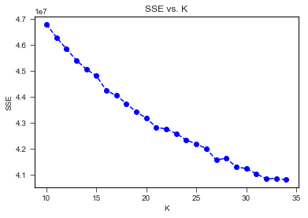

```python
def get_kmeans_score(data, center):
    '''
    returns the kmeans score regarding SSE for points to centers
    INPUT:
        data - the dataset you want to fit kmeans to
        center - the number of centers you want (the k value)
    OUTPUT:
        score - the SSE score for the kmeans model fit to the data
    '''
    #instantiate kmeans
    kmeans = KMeans(n_clusters=center)

    # Then fit the model to your data using the fit method
    model = kmeans.fit(data)

    # Obtain a score related to the model fit
    score = np.abs(model.score(data))

    return score

scores = []
centers = list(range(10,35))

for center in centers:
    scores.append(get_kmeans_score(azdias, center))

plt.plot(centers, scores, linestyle='--', marker='o', color='b');
plt.xlabel('K');
plt.ylabel('SSE');
plt.title('SSE vs. K');
```

```python
# Re-fit the k-means model with the selected number of clusters and obtain
# cluster predictions for the general population demographics data.
kmeans = KMeans(n_clusters = 32)
azdias_clusters = kmeans.fit_predict(azdias);
```

### Discussion 3.1: Apply Clustering to General Population

From the graph above, there is an 'elbow' at K=32 clusters, and so I decided to segment the population into 32 clusters.

### Step 3.2: Applying All Steps to the Customer Data

It's now time to see how the customer data maps on to the clusters from the general population. I will use the fits from the general population to clean, transform, and cluster the customer dataand then interpret how the general population fits apply to the customer data.

```python
# Load in the customer demographics data.
customers = pd.read_csv("Udacity_CUSTOMERS_Subset.csv", sep=";")
```

```python
#Clean the customer demographics data.

new_customers = clean_data(customers)
```

```python
scaler
```

```
StandardScaler(copy=True, with_mean=True, with_std=True)
```

```python
new_customers.head()
```

|  | ALTERSKATEGORIE_GROB | ANREDE_KZ | FINANZ_MINIMALIST | FINANZ_SPARER | FINANZ_VORSORGER | FINANZ_ANLEGER | FINANZ_UNAUFFAELLIGER | FINANZ_HAUSBAUER | GREEN_AVANTGARDE | HEALTH_TYP | ... | CAMEO_DEUG_2015_5 | CAMEO_DEUG_2015_6 | CAMEO_DEUG_2015_7 | CAMEO_DEUG_2015_8 | CAMEO_DEUG_2015_9 | PJ_decade | PJ_movement | CAMEO_INTL_wealth | CAMEO_INTL_life_stage | PLZ8_BAUMAX_buildings |
| --- | --- | --- | --- | --- | --- | --- | --- | --- | --- | --- | --- | --- | --- | --- | --- | --- | --- | --- | --- | --- | --- |
| 0 | 4.0 | 1 | 5 | 1 | 5 | 1 | 2 | 2 | 1 | 1.0 | ... | 0 | 0 | 0 | 0 | 0 | 2.0 | 2.0 | 1 | 3 | 1.0 |
| 2 | 4.0 | 2 | 5 | 1 | 5 | 1 | 4 | 4 | 1 | 2.0 | ... | 1 | 0 | 0 | 0 | 0 | 2.0 | 2.0 | 3 | 4 | 1.0 |
| 4 | 3.0 | 1 | 3 | 1 | 4 | 4 | 5 | 2 | 0 | 3.0 | ... | 0 | 0 | 1 | 0 | 0 | 4.0 | 1.0 | 4 | 1 | 1.0 |
| 5 | 3.0 | 1 | 5 | 1 | 5 | 1 | 2 | 3 | 1 | 3.0 | ... | 1 | 0 | 0 | 0 | 0 | 2.0 | 2.0 | 3 | 4 | 1.0 |
| 6 | 4.0 | 1 | 5 | 1 | 5 | 1 | 1 | 2 | 1 | 2.0 | ... | 0 | 0 | 0 | 0 | 0 | 2.0 | 2.0 | 2 | 3 | 1.0 |

5 rows × 122 columns

```python
# Apply preprocessing, feature transformation, and clustering from the general
# demographics onto the customer data, obtaining cluster predictions for the
# customer demographics data.

standard_scaled_customers = scaler.transform(new_customers)
standard_scaled_customers = pd.DataFrame(standard_scaled_customers, columns=list(new_customers))

customer_df = pd.DataFrame(pca.transform(standard_scaled_customers))


customer_clusters = kmeans.predict(customer_df);
```